# The Concussion Conundrum

Nathan Ellisen, Cullen Shoquist, Gray Hooper, Andrew Le

2/18/2022

*(NFL-CD)*

*nathanellisen@gmail.com, cullenshoquist@gmail.com, gnhooper@uw.edu, ale527@uw.edu*

Info-201: Technical Foundations of Informatics - The Information School - Univeristy of Washington

Winter 2022

### Our Goal

We are concerned with how the number of concussion that occur in the NFL correlate with various predetermined pertinent information that could correlate with the causation of a concussion. To address this concern, we plan to compare data on a game-by-game basis of concussions recorded versus the players demographics, team data, and game by game information to get to the bottom of what could be a predictor of more/less concussion in a game and for a player.

### Keywords

Concussion, NFL, Age, Team, Football, Sports

## 1.0 Introduction

Known as “America’s sport,” football is a game that is celebrated across the country. Consisting of spectacular feats of athletic performance, football woos everyone who watches- but what about the players? With these feats of athleticism comes repercussions for the players- and most commonly, head injuries and neurological damage. With the nature of the game, there isn’t much that could be done to reduce these injuries without completely changing the culture and rulings of the game. Although it would be beneficial for the players, they disagree with any kind of change to the game, and almost accept head injuries as a guarantee and cost of playing football at a high level. However, head injuries occur at every level of the sport, and with exploration of data, and context of the sport we can come up with some sort of solution that will not hinder the experience of the sport, as well as maximize the safety of the players.

## 2.0 Design situation

It is well known that concussions are a hot topic in the NFL. NFL’s management consistently denies any wrongdoing and seemingly implements unhelpful rules every time the issue reaches the public arena. Clearly there is a lot at stake with the issue, so let’s break it down into a few components.

**The Issue Itself:**

Athletes and their family/friends across the world are aware of the dangers of concussions. But what really is the concern? According to Missouri Health Care, Chronic Traumatic Encephalopathy, hereafter referred to as CTE, is the primary long-term effect of repeated concussions. CTE “causes the brain to break down, leading to memory loss, depression, and even dementia.” Clearly these are dangers that the NFL and every football player/parent should be aware of.

**The Opinions in Play:**

The most prominent and polarized opinions lie either in trying to protect the players themselves or the game of football. Those with serious concern for the players, oftentimes parents of children growing up playing the sport, think the NFL sets the standard for the rest of football play across the country. According to CNBC, “90 out of 94 deceased former NFL players had brains that showed evidence of brain disease”, and parents feel the NFL has a responsibility to create a safe playing space that will trickle down to pee-wee football. On the other hand, many football traditionalists feel the many rule changes the NFL has already put into place are more than enough. This includes many current players who don’t want the game they group up loving to change drastically. According to the University of Rochester’s Campus Times, “Redskins safety D.J. Swearinger claimed that he ‘didn’t sign up to play two-hand touch’ while Vikings safety Andrew Sendejo has been seen wearing a ‘Make Football Violent Again’ hat”. Clearly there are varying stances on the matter.

**Stakeholders:**

The primary stakeholders are of course the players and the NFL itself. Franchises need to make money, as do players, and that all comes from viewership. If the NFL were to all of a sudden switch to “two-hand touch”, they surely would lose much viewership. However, if they keep consistently losing players to CTE, they also will lose viewership. Additionally, players scared of the dangers of concussions and CTE are more likely to side with those wanting more regulation, whereas many defenders such as Swearinger and Sendejo want the game to remain the traditional game it has always been. Indirect stakeholders would surely include those with personal connections to both owners and players, alongside the fans who watch the games and want the most entertaining of media.

**Impacts of Data and Technology:**

The NFL has used data and technology many times to assess the concern surrounding concussions. Certainly the primary flaw in this strategy is it reduces human lives into numbers. Yes, we can count the number of concussions results using various rules, and can use data to theorize what strategy will work to maximize profit and minimize danger. Yet, this problem can’t be reduced to just numbers. There are too many factors at play to create a comprehensive solution with data alone. That being said, using statistics to make predictions about what rules and regulations the NFL implements to maximize safety and keep the sport we love are great, so long as they are judged from a qualitative perspective for its true impacts before implementation.

*Works Cited*

[Concussion Impact](https://www.justicepays.com/learning/injury/why-concussions-are-so-dangerous-and-can-leave-lasting-problems#:~:text=If%20someone%20suffers%20enough%20concussions,%2C%20depression%2C%20and%20even%20dementia)

[NFL Policy Changes](https://www.cnbc.com/2016/04/24/nfl-needs-big-changes-to-concussion-policy-and-so-does-everyone-else-expert.html)

[“The NFL is Soft”](http://www.campustimes.org/2018/10/04/are-nfl-rule-changes-making-the-league-soft/)

*For Proper Citations See “References”*

## 3.0 Research Questions

**What factors contribute the most to concussions?**

**Do the factors most to blame pertain more to certain positions over others?**

**Are the primary contributors to concussions preventable?**

**Can these findings help inform more safety protocols for the NFL?**

These research questions are motivated by a desire to uncover factors contributing to concussions in NFL players that may have been overlooked in the past. Ideally, findings of this nature would propel the NFL to consider new safety protocols in new parts of the game. This is important because brain damage from football is a problem that has garnered some attention, but still has not been addressed fully. The hope is that when considering a dataset like this some new potential contributors to concussions and CTE may be uncovered.

## 4.0 The dataset

As our group decided to look at concussion data for players in the NFL, we wanted a good sized data set. Because there are less than 2000 players in the league and not all of them always get concussions, we knew it would take multiple seasons to get enough data. We were able to find a data set that spanned from the years 2012-2014, three seasons worth of concussion data. Over three seasons, our data set has logged 393 concussions. While this data set size is on the smaller side, the NFL has such a small set of observable subjects that a 25% population size sample felt very appropriate. The other reason we thought this was an adequate data set was because it had so much data on each concussion, with 18 different columns of information spanning from opponent in game concussed, to previous injury history, to weeks out due to injury. This high level of detail about each concussion will allow us to make groupings and find different patterns within the data to help us figure out factors that play into concussions as well as finding ways in which the league may be lacking in their protocol. The specific entries are by each diagnosed concussion that has taken place in the NFL (there are probably many concussions in the NFL that go undiagnosed that are not included). The player that received the concussion is also logged and will serve as our key to find certain incidents and keep track of rows. NFL data is pretty public knowledge, with NFL injuries and stats being posted all over websites like ESPN and NFL.com. We found our data on Kaggle.com but there it acknowledges user Alice C on data.world for creating the original data set. While Alice C is not a widely known figure, The data appears to be accurate as we have checked on a few selected concussions listed with our own research and they have matched up, leading us to believe the data set is trustworthy. Assumably, this data is collected for the purpose of highlighting the NFL’s continuous concussion problem, which has been an on going issue in the NFL ever since research has come out regarding the negative effects of concussions long term. There is no one directly profiting from this data as it was all freely available but those who wish to shed light on the NFL’s concussion issue may benefit from the data as others will see what they have found.

## 5.0 Expected Implications

If we are able to find some interesting correlative relationships in this dataset, there could be some large implications for the NFL. The NFL has gotten a lot better about implementing safety rules both on and off the field to help address the growing prevalence of CTE in its players, but more can still be done. Finding trends in this dataset could go to help the NFL design more rules to prevent brain damage, and further than that, if the findings were to go public the NFL would face a lot of pressure to implement changes to reflect the findings. In this way, working with the research questions and this dataset could have extensive implications for the brain health of players in the NFL.

## 6.0 Limitations

The limitations that are needed to address would be the context of the sport aside from the data. The data in the end is just numbers, and with football- and a lot of sports, not everything is about numbers. There is context that is not shown within the data set, and that cannot be measured using code- and must be taken into account. The narratives at play, the social repercussions, the impacts on the sport, and the morales of those involved is just not something that you can quantify. Although a solution can be brought forth using the data of the seasons played, will the solution work how we want? Will the people react to the solution as intended?

## P02

For the first function we wanted to see how many games the average player missed due to concussion, which we found to be 0.8520408 We thought that this would be a valuable value to get as it would allow us to assess either the severity of the concussions. Our result came out to less than one game missed per concussion. This is concerning as it potentially means that the NFL is not taking concussions as seriously as they should.

For this function we wanted to see which month had the most concussions. We thought it would be valuable to look at if certain months were potentially the most dangerous and draw conclusions based on that.The highest month was September, maybe due to players hitting harder at the start of the season. The league should look to more tightly enforce unnecessary roughness penalties at the start of the season. The most concussions a single month had was 107

For this last function we wanted to see if there was a connection between pre-season injuries and concussion. We thought it would be valuable to look at because re-injury is often a problem, especially with head injuries. It turned out to be only 0.0663265 percent of all players who were concussed had an injury in the pre-season.

| rn | Position | Concussion.Frequency | Average.Week.of.Injury | Average.Weeks.Injured | Average.Games.Missed | Average.Downs.Played.Before.Injury | Average.Downs.Played.After.Injury |
| --- | --- | --- | --- | --- | --- | --- | --- |
| 1 | Center | 6 | 9 | 1 | 0 | 55 | 64 |
| 2 | Comerback | 53 | 8 | 1 | 1 | 49 | 55 |
| 3 | Defensive End | 17 | 9 | 1 | 1 | 43 | 39 |
| 4 | Defensive Tackle | 10 | 9 | 1 | 1 | 36 | 33 |
| 5 | Full Back | 2 | 11 | 1 | 0 | 36 | 29 |
| 6 | Guard | 21 | 11 | 1 | 1 | 60 | 67 |
| 7 | Linebacker | 32 | 7 | 1 | 1 | 51 | 45 |
| 8 | Long Snapper | 1 | 1 | 1 | 0 | NaN | 12 |
| 9 | Offensive Tackle | 15 | 9 | 1 | 1 | 67 | 69 |
| 10 | Quarterback | 11 | 9 | 1 | 2 | 60 | 53 |
| 11 | Running Back | 32 | 9 | 1 | 1 | 32 | 34 |
| 12 | Safety | 46 | 9 | 1 | 1 | 51 | 56 |
| 13 | Tight End | 29 | 10 | 1 | 2 | 45 | 41 |
| 14 | Wide Receiver | 43 | 8 | 1 | 1 | 40 | 38 |

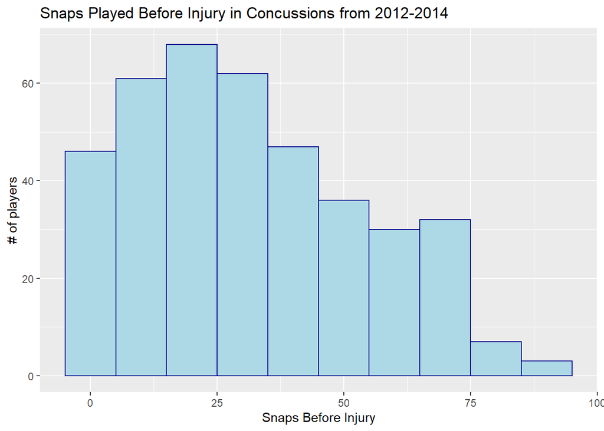

This chart was intended to show if there is a relationship between the number of snaps taken before concussion and the frequency at which concussions occur at the given number of snaps. The chart indicates that concussions are more likely to occur earlier in the game (centered at 15 to 25 snaps). The frequency of concussion peaks at this bin and decreases gradually as the number of snaps increases.

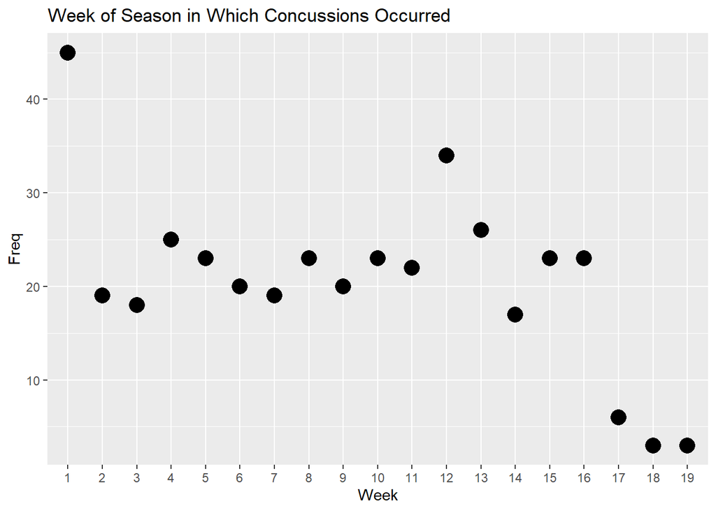

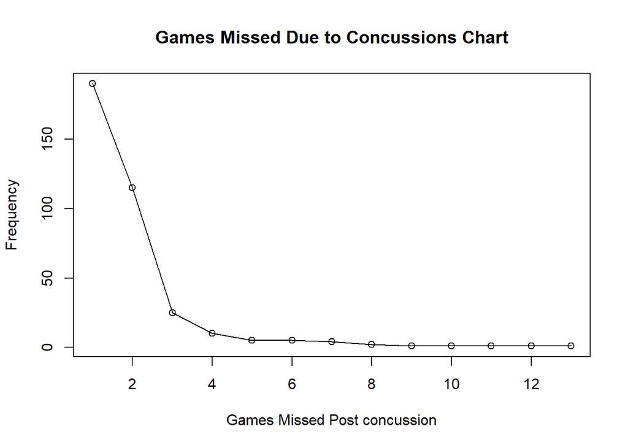

### Acknowledgements

We would like to thank the creator of this data set on Kaggle for publicizing this data.

### References

#### *Works Cited*

##### Cez Garcia “Are NFL Rule Changes Making the League ‘Soft’?”

October 04, 2018, et al. “Are NFL Rule Changes Making the League ‘Soft’?” Campus Times, 8 Oct. 2018, http://www.campustimes.org/2018/10/04/are-nfl-rule-changes-making-the-league-soft/.

##### Goldman, David L. “Why Concussions Are so Dangerous and Can Leave Lasting Problems.”

Goldman Babboni Fernandez & Walsh Auto Accidents Personal Injury, 2016, https://www.justicepays.com/learning/injury/why-concussions-are-so-dangerous-and-can-leave-lasting-problems#:~:text=If%20someone%20suffers%20enough%20concussions,%2C%20depression%2C%20and%20even%20dementia.

##### trentCNBC. “NFL Needs Big Changes to Concussion Policy, and so Does Everyone Else: Expert.”

CNBC, CNBC, 24 Apr. 2016, https://www.cnbc.com/2016/04/24/nfl-needs-big-changes-to-concussion-policy-and-so-does-everyone-else-expert.html.